# Mineralogical Composition of Igneous Rocks

Dr. Ahmad Redaa

2024-09-11

# Classification of Minerals in Igneous Rocks

## Primary Minerals

- Primary minerals crystallize directly from magma as it cools and solidifies. They form the main framework of igneous rocks.

## Accessory Minerals

- Accessory minerals are present in minor quantities and do not significantly affect the rock’s classification, but they provide critical information about the rock’s geological history.
- Examples: Zircon, Apatite, and Magnetite.

## Secondary Minerals

- Secondary minerals are produced by the alteration of primary minerals after the rock has formed. This occurs due to chemical weathering or hydrothermal processes.
- Examples: Chlorite, Serpentine, and Epidote.

# Bowen’s reaction series

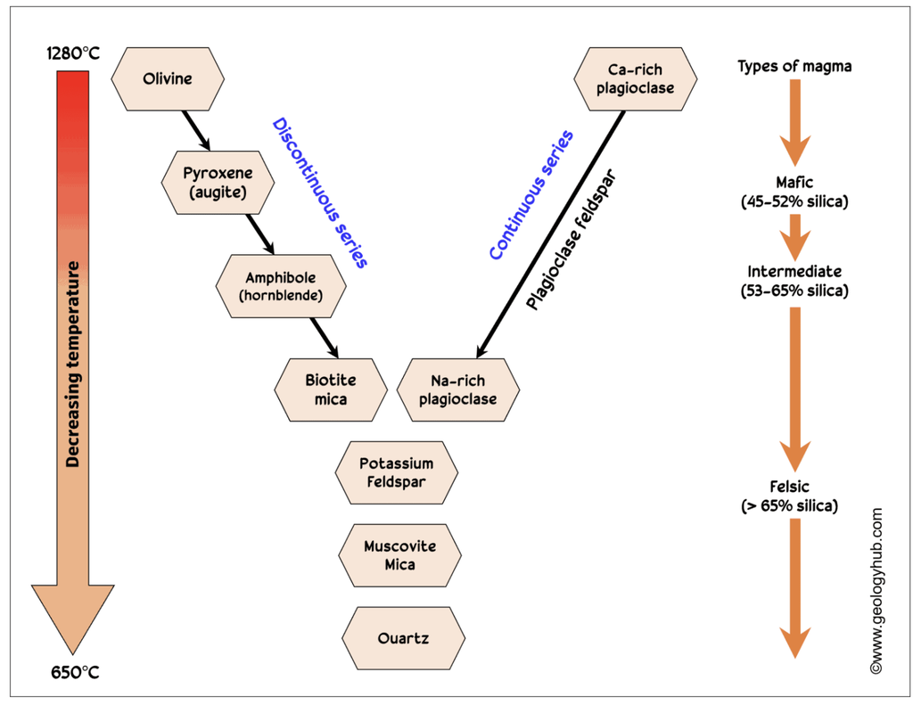

Bowen’s reaction series, Source: [https://geologyhub.com](https://geologyhub.com/bowens-reaction-series/)

# Mafic Minerals

- Mafic minerals are rich in magnesium (Mg) and iron (Fe), hence the name “mafic” (derived from magnesium and ferric).
- Typically dark-colored, they form in high-temperature conditions and are prevalent in basaltic and other mafic igneous rocks.

# Felsic Minerals

- Primarily composed of quartz, feldspars, and muscovite, these minerals are rich in silicon and aluminum.
- Typically light-colored, they form under lower temperature conditions compared to mafic minerals and are predominant in rocks like granite and rhyolite.

# Olivine Group

## Chemical Composition of Olivine Series

$$\text{(Mg, Fe)}_2\text{SiO}_4$$

- The series forms a solid solution between these two endmembers, with varying Mg and Fe content.
1. **Forsterite (Mg₂SiO₄)**
   - Rich in **magnesium**.
   - Chemical composition: **Mg₂SiO₄**.
2. **Fayalite (Fe₂SiO₄)**
   - Rich in **iron**.
   - Chemical composition: **Fe₂SiO₄**.

# Olivine in Thin-Section (Microscope Features)

- **Color**: Pale to light green or colorless in plane-polarized light.
- **Cleavage**: Poor or absent, with irregular fractures.
- **Birefringence**: Moderate to high (up to 3rd-order colors under crossed polars).
- **Crystal Habit**: Anhedral to subhedral grains, often with irregular shapes.
- **Other Features**: Shows characteristic **high relief** and commonly displays **fractures**.

For a detailed example of olivine’s appearance under a microscope in thin-section, visit [Olivine Thin Section Example](http://microckscopic.ro/minerals/silicates/nesosilicates/olivine-thin-section/).

# Pyroxene Group

1. **Clinopyroxene (CPX)**
   - Key Mineral: **Augite** `(Ca, Na)(Mg, Fe, Al)(Si, Al)₂O₆`
   - Other Example: **Diopside** `CaMgSi₂O₆`
   - Structure: Monoclinic
   - Main Features: High relief, inclined extinction, and simple twinning in thin section.

   Thin section examples:  
   [Augite Thin Section](http://microckscopic.ro/minerals/silicates/inosilicates/single-chain-inosilicates/augite-thin-section/)  
   [Diopside Thin Section](http://microckscopic.ro/minerals/silicates/inosilicates/single-chain-inosilicates/diopside-thin-section/)
2. **Orthopyroxene (OPX)**
   - Key Mineral: **Enstatite** `(Mg, Fe)₂Si₂O₆`
   - Structure: Orthorhombic
   - Main Features: Moderate relief, straight extinction, and lamellar twinning in thin section.

   Thin section example:  
   [Enstatite-Ferrosilite Thin Section](http://microckscopic.ro/minerals/silicates/inosilicates/single-chain-inosilicates/enstatite-ferrosilite-thin-section/)
3. **Alkali Pyroxene**
   - Key Mineral: **Aegirine (Acmite)** `NaFe³⁺Si₂O₆`
   - Structure: Monoclinic
   - Main Features: Very high relief, bright green color, and strong pleochroism in thin section.

   Thin section example:  
   [Aegirine (Acmite) Thin Section](http://microckscopic.ro/minerals/silicates/inosilicates/single-chain-inosilicates/aegirine-acmite-thin-section/)
- **CPX vs OPX**:
  - Clinopyroxenes have monoclinic symmetry, while orthopyroxenes are orthorhombic.
  - CPX shows inclined extinction, while OPX shows straight extinction.
- **Alkali Pyroxene vs CPX/OPX**:
  - Alkali pyroxenes are richer in sodium and exhibit more intense pleochroism and higher relief compared to CPX and OPX.

# Amphibole Group

1. **Hornblende**
   - **Composition**: $(Ca,Na)_2-3(Mg,Fe,Al)_5(Si,Al)_8O_{22}(OH)_2$
   - Common in diorite.
   - Typically dark green to black.
   - Common features in thin section: High relief, two cleavages at 60° and 120°, strong pleochroism from green to brown.
   - Thin section example:  
     [Hornblende thin section](http://microckscopic.ro/minerals/silicates/inosilicates/double-chain-inosilicates/hornblende-thin-section)

# Mica Group

1. Biotite
   - Composition: $K(Mg,Fe)_3AlSi_3O_{10}(OH)_2$
   - Appearance: Dark brown to black, containing iron and magnesium.
   - Common Locations: Found in granites, syenites, and diorites.
2. Muscovite
   - Composition: $KAl_2(AlSi_3O_{10})(OH)_2$
   - Appearance: Colorless to pale silvery or brown, richer in aluminum.
   - Common Locations: Predominantly in granitic rocks and pegmatites.

## Properties and Identification in Thin Section

- **Biotite**:
  - **Color**: Dark brown to black.
  - **Pleochroism**: Strong, varying from dark brown to yellowish-brown.
  - **Cleavage**: Perfect in one direction, sheets flexible.
  - **Thin Section Example**: [View Biotite in Thin Section](http://microckscopic.ro/minerals/silicates/phyllosilicates/biotite-thin-section/)
- **Muscovite**:
  - **Color**: Colorless to pale brown or silvery.
  - **Pleochroism**: Minimal to absent.
  - **Cleavage**: Perfect, sheets flexible and elastic.
  - **Thin Section Example**: [View Muscovite in Thin Section](http://microckscopic.ro/minerals/silicates/phyllosilicates/muscovite-thin-section/)

# Feldspar Group

## Plagioclase minerals

1. **Albite** $\text{NaAlSi}_3\text{O}_8$
2. **Oligoclase** $\text{Na,CaAl}_1\text{-2}\text{Si}_3\text{-2}\text{O}_8$
3. **Andesine** $\text{(Na,Ca)(Al,Si)AlSi}_2\text{O}_8$
4. **Labradorite** $\text{(Ca,Na)Al}_1\text{-2}\text{Si}_2\text{-3}\text{O}_8$
5. **Bytownite** $\text{(Ca,Na)(Al,Si)AlSi}_2\text{O}_8$
6. **Anorthite** $\text{CaAl}_2\text{Si}_2\text{O}_8$
- Forms a solid solution series from sodium-rich albite to calcium-rich anorthite.
- **Appearance**: Can show striations on cleavage faces in thin sections.
- **Color**: Ranges from colorless to shades of white, gray, or blue.

## K-Feldspar (Orthoclase, Microcline, and Sanidine)

- **Chemical Formulas**:
  - **Orthoclase**: $\text{KAlSi}_3\text{O}_8$
  - **Microcline**: Same composition but triclinic crystal structure.
  - **Sanidine**: High-temperature polymorph of K-Feldspar, more commonly found in volcanic rocks.
- **Features**:
  - **Orthoclase**: Typically pink, showing simple twinning in thin sections.
  - **Microcline**: Often displays grid-like tartan twinning.
  - **Sanidine**: Appears more glassy and can have a clear or slightly cloudy appearance with less distinct twinning.
- **Role in Igneous Rocks**: Indicator of silica saturation and cooling history.

## Properties in Thin Section

- **Cleavage**: Two directions at nearly 90°.
- **Twinning**:
  - Plagioclase shows polysynthetic twinning.
  - K-Feldspar may show Carlsbad, Manebach, or Baveno twinning.
- **Optical Properties**:
  - Both plagioclase and K-feldspar have low to moderate relief and birefringence.
- **Thin Section Example for Orthoclase**: [View Orthoclase in Thin Section](http://microckscopic.ro/minerals/silicates/tectosilicates/orthoclase-thin-section/)
- **Thin Section Example**: [View Plagioclase in Thin Section](http://microckscopic.ro/minerals/silicates/tectosilicates/plagioclase-thin-section/)

# Quartz

- One of the most abundant minerals in the Earth’s crust, known for its chemical and physical durability.
- **Chemical Formula**: $\text{SiO}_2$

## Properties in Thin Section

- **Color**: Colorless in thin section.
- **Optical Properties**:
  - High hardness and lack of cleavage.
  - Conchoidal fracture.
  - Low birefringence, typically showing low interference colors.
  - No pleochroism.
- **Quartz Thin Section Example**: View how Quartz appears under the microscope and its typical optical properties: [View Quartz in Thin Section](http://microckscopic.ro/minerals/silicates/tectosilicates/quartz-thin-section/)

# Zircon

## Chemical Composition

- **Zircon**: $\text{ZrSiO}_4$
- Commonly incorporates trace amounts of hafnium, uranium, and thorium.

## Importance in Petrology

- **Geochronology**: Extensively used for U-Pb dating due to its resistance to weathering and high closure temperature.
- **Indicator of Magmatic Processes**: Indicates the level of zirconium saturation in magma, aiding in understanding magmatic evolution.

## Optical Properties in Thin Section

- **High Refractive Index**: Leads to a high relief appearance.
- **Birefringence**: Generally low but noticeable due to its high dispersion.
- **Pleochroism**: Typically not pleochroic but can exhibit color changes in cathodoluminescence.
- See Zircon in a thin section: [View Zircon Thin Section](http://microckscopic.ro/minerals/silicates/nesosilicates/zircon-thin-section/)

## Common Occurrences

- **Granites**: Commonly found in granites, visible as small, resistant grains.
- **Pegmatites**: Crystallizes in pegmatitic environments where it can grow larger.
- **Metamorphic Rocks**: Found in schists and gneisses, preserving metamorphic histories.

# Apatite

## Chemical Composition

- **Apatite**: $\text{Ca}_5(\text{PO}_4)_3(\text{OH}, \text{Cl}, \text{F})$
- Commonly incorporates trace amounts of strontium, lead, and rare earth elements.

## Importance in Petrology

- **Geochemistry**: Used to trace phosphorus in magmatic systems and is a key indicator of different geological environments.
- **Geochronology**: Sometimes used for U-Pb dating to determine cooling ages of rocks due to its uranium content.

## Optical Properties in Thin Section

- **Moderate Refractive Index**: Results in moderate relief in thin sections.
- **Birefringence**: Typically high, showing bright interference colors.
- **Pleochroism**: Generally not pleochroic, but can show color differences in different crystal orientations.
- [View Apatite Thin Section](http://microckscopic.ro/minerals/silicates/nesosilicates/apatite-thin-section/)

## Common Occurrences

- **Granites**: Frequently found in granitic rocks as small, hexagonal crystals.
- **Pegmatites**: Large, well-formed crystals common in pegmatitic environments.
- **Metamorphic Rocks**: Present in metamorphic rocks, indicating phosphorus content during metamorphism.

# Chlorite

- **Chlorite**: A group of phyllosilicate minerals typically composed of $\text{Mg, Al, Fe}^{2+}, \text{Fe}^{3+}, \text{Mn, Ni, Zn}$ in combination with $\text{Si, Al}$ and $\text{O}_4$ with $\text{OH}$.
- Often includes hydroxide ions alongside magnesium, iron, and aluminum silicates.
- **Formation**: Chlorite commonly forms during the alteration of iron-rich minerals like biotite, amphibole, or pyroxene through hydrothermal processes or during the low to moderate temperature metamorphism of these minerals.
- Acts as a retrograde metamorphic mineral, indicating conditions of cooling and fluid availability post-peak metamorphism.
- Occurs as an alteration product in igneous rocks, particularly in volcanic environments.

## Optical Properties in Thin Section

- **Color**: Typically green to greenish-black.
- **Pleochroism**: Exhibits strong pleochroism from pale green to dark green.
- **Birefringence**: Generally low, often appears as low-order interference colors.
- **Cleavage**: Excellent basal cleavage, appearing as flakes or plates.
- [View Chlorite Thin Section](http://microckscopic.ro/minerals/silicates/phyllosilicates/chlorite-thin-section/)

# Epidote

- **Epidote**: $\text{Ca}_2(\text{Al, Fe}^{3+})_3(\text{SiO}_4)_3(\text{OH})$
- Comprises a series where Fe and Al substitution varies the member minerals from Clinozoisite (Al-rich) to Epidote (Fe-rich).
- **Formation**: Typically forms during the low to high-grade metamorphism of calcium-rich rocks and as an alteration product in igneous rocks under hydrothermal conditions.
- Often found in areas with high pressure and temperature conditions that facilitate the alteration of plagioclase feldspars.

### Optical Properties in Thin Section

- **Color**: Ranges from pistachio green to yellow-green.
- **Pleochroism**: Strong, with colors shifting from yellow to green depending on the orientation.
- **Birefringence**: High, showing second-order interference colors.
- **Cleavage**: Distinct one-directional cleavage, parallel to crystal length.
- [View Epidote Thin Section](http://microckscopic.ro/minerals/silicates/sorosilicates/clinozoisite-epidote-thin-section/)